# Statistical linear regression models

## Basic regression model with additive Gaussian errors.

- Least squares is an estimation tool, how do we do inference?
- Consider developing a probabilistic model for linear regression
  $$Y_i = \beta_0 + \beta_1 X_i + \epsilon_{i}$$
- Here the $\epsilon_{i}$ are assumed iid $N(0, \sigma^2)$.
- Note, $E[Y_i ~|~ X_i = x_i] = \mu_i = \beta_0 + \beta_1 x_i$
- Note, $Var(Y_i ~|~ X_i = x_i) = \sigma^2$.

[wikipedia](https://en.wikipedia.org/wiki/Gauss%E2%80%93Markov_theorem)

[more info](https://stats.stackexchange.com/questions/72424/what-is-random-error-in-ols-regression-and-how-is-it-related-to-gaussian-noise)

## Recap

- Model $Y_i = \mu_i + \epsilon_i = \beta_0 + \beta_1 X_i + \epsilon_i$ where $\epsilon_i$ are iid $N(0, \sigma^2)$
- ML estimates of $\beta_0$ and $\beta_1$ are the least squares estimates
  $$\hat \beta_1 = Cor(Y, X) \frac{Sd(Y)}{Sd(X)} ~~~ \hat \beta_0 = \bar Y - \hat \beta_1 \bar X$$
- $E[Y ~|~ X = x] = \beta_0 + \beta_1 x$
- $Var(Y ~|~ X = x) = \sigma^2$

## Interpretting regression coefficients, the itc

- $\beta_0$ is the expected value of the response when the predictor is 0
  $$E[Y | X = 0] = \beta_0 + \beta_1 \times 0 = \beta_0$$
- Note, this isn’t always of interest, for example when $X=0$ is impossible or far outside of the range of data. (X is blood pressure, or height etc.)
- Consider that
  $$Y_i = \beta_0 + \beta_1 X_i + \epsilon_i
  = \beta_0 + a \beta_1 + \beta_1 (X_i - a) + \epsilon_i
  = \tilde \beta_0 + \beta_1 (X_i - a) + \epsilon_i$$
  So, shifting your $X$ values by value $a$ changes the intercept, but not the slope.
- Often $a$ is set to $\bar X$ so that the intercept is interpretted as the expected response at the average $X$ value.

## Interpretting regression coefficients, the slope

- $\beta_1$ is the expected change in response for a 1 unit change in the predictor
  $$E[Y ~|~ X = x+1] - E[Y ~|~ X = x] =
  \beta_0 + \beta_1 (x + 1) - (\beta_0 + \beta_1 x ) = \beta_1$$
- Consider the impact of changing the units of $X$.
  $$Y_i = \beta_0 + \beta_1 X_i + \epsilon_i
  = \beta_0 + \frac{\beta_1}{a} (X_i a) + \epsilon_i
  = \beta_0 + \tilde \beta_1 (X_i a) + \epsilon_i$$
- Therefore, multiplication of $X$ by a factor $a$ results in dividing the coefficient by a factor of $a$.
- Example: $X$ is height in $m$ and $Y$ is weight in $kg$. Then $\beta_1$ is $kg/m$. Converting $X$ to $cm$ implies multiplying $X$ by $100 cm/m$. To get $\beta_1$ in the right units, we have to divide by $100 cm /m$ to get it to have the right units.
  $$X m \times \frac{100cm}{m} = (100 X) cm
  ~~\mbox{and}~~
  \beta_1 \frac{kg}{m} \times\frac{1 m}{100cm} =
  \left(\frac{\beta_1}{100}\right)\frac{kg}{cm}$$

## Using regression coeficients for prediction

- If we would like to guess the outcome at a particular value of the predictor, say $X$, the regression model guesses
  $$\hat \beta_0 + \hat \beta_1 X$$

## Example

### `diamond` data set from `UsingR`

Data is diamond prices (Singapore dollars) and diamond weight in carats (standard measure of diamond mass, 0.2 $g$). To get the data use `library(UsingR); data(diamond)`

## Plot of the data

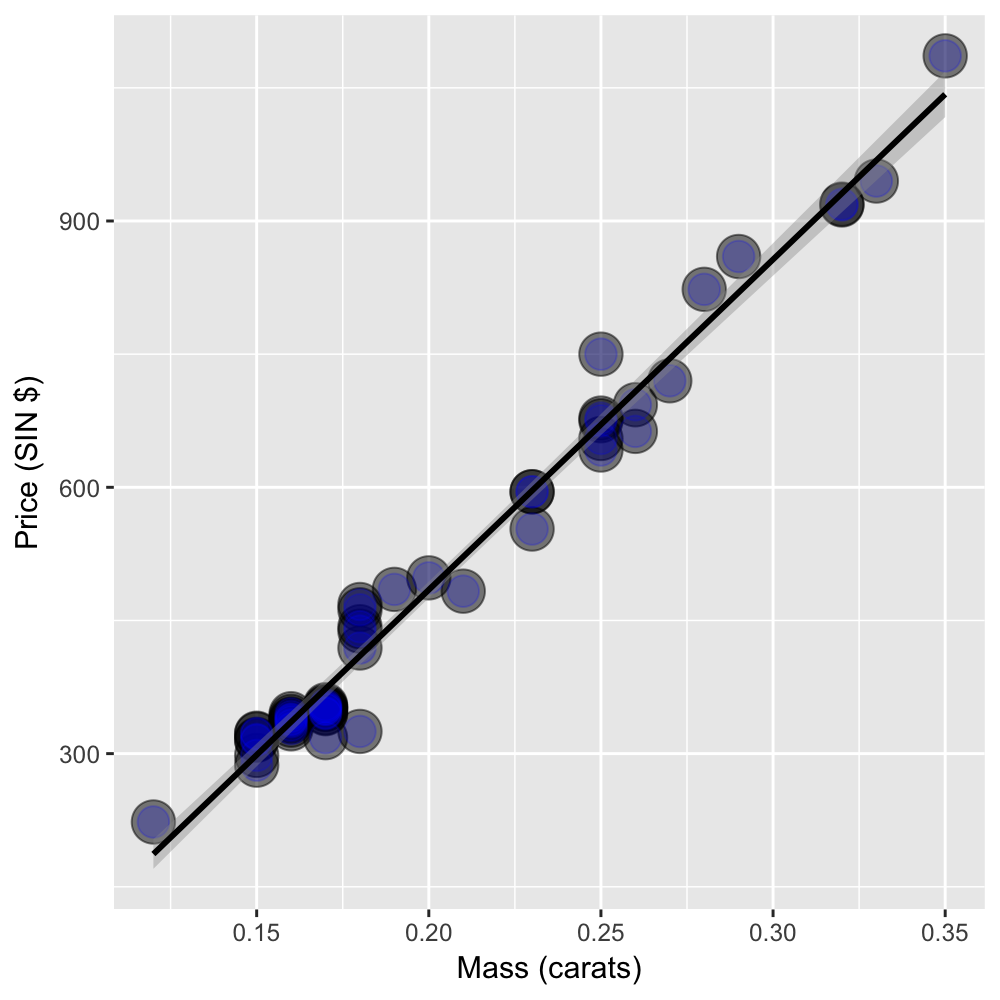

## Fitting the linear regression model

```r
fit <- lm(price ~ carat, data = diamond)
coef(fit)
```

```
(Intercept)       carat
  -259.6259   3721.0249
```

- We estimate an expected 3721.02 (SIN) dollar increase in price for every carat increase in mass of diamond.
- The intercept -259.63 is the expected price of a 0 carat diamond.

## Getting a more interpretable intercept

```r
# centering the predictor
fit2 <- lm(price ~ I(carat - mean(carat)), data = diamond)
coef(fit2)
```

```
           (Intercept) I(carat - mean(carat))
              500.0833              3721.0249
```

```r
# slopes stays the same
# intercept changes. Therefore the intercept from fit2 is the expected price
# for the average sized diamond os the data (0.2042 carats)
```

Thus $500.1 is the expected price for the average sized diamond of the data (0.2041667 carats).

## Changing scale

- A one carat increase in a diamond is pretty big, what about changing units to 1/10th of a carat?
- We can just do this by just dividing the coeficient by 10.
  - We expect a 372.102 (SIN) dollar change in price for every 1/10th of a carat increase in mass of diamond.
- Showing that it’s the same if we rescale the Xs and refit

```r
fit3 <- lm(price ~ I(carat * 10), data = diamond)
coef(fit3)
```

```
  (Intercept) I(carat * 10)
    -259.6259      372.1025
```

## Predicting the price of a diamond

```r
newx <- c(0.16, 0.27, 0.34)
coef(fit)[1] + coef(fit)[2] * newx
```

```
[1]  335.7381  745.0508 1005.5225
```

```r
predict(fit, newdata = data.frame(carat = newx))
```

```
        1         2         3
 335.7381  745.0508 1005.5225
```

Predicted values at the observed Xs (red) and at the new Xs (lines)

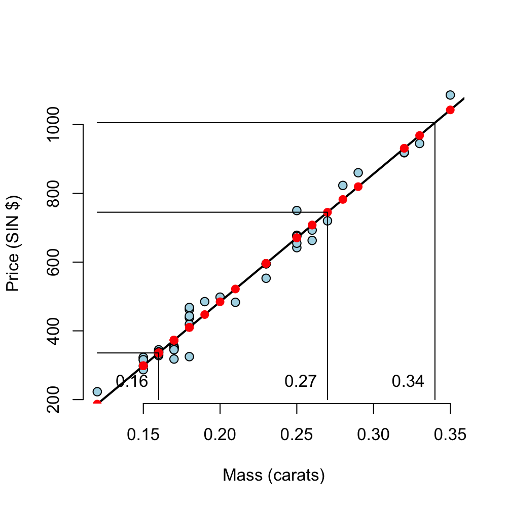

## Exercises

1. Fit a linear regression model to the father.son dataset with the father as the predictor and the son as the outcome. Give a p-value for the slope coefficient and perform the relevant hypothesis test

```
Call:
lm(formula = y ~ x)

Residuals:
    Min      1Q  Median      3Q     Max
-8.8772 -1.5144 -0.0079  1.6285  8.9685

Coefficients:
            Estimate Std. Error t value Pr(>|t|)
(Intercept) 33.88660    1.83235   18.49   <2e-16 ***
x            0.51409    0.02705   19.01   <2e-16 ***
---
Signif. codes:  0 '***' 0.001 '**' 0.01 '*' 0.05 '.' 0.1 ' ' 1

Residual standard error: 2.437 on 1076 degrees of freedom
Multiple R-squared:  0.2513,    Adjusted R-squared:  0.2506
F-statistic: 361.2 on 1 and 1076 DF,  p-value: < 2.2e-16
```

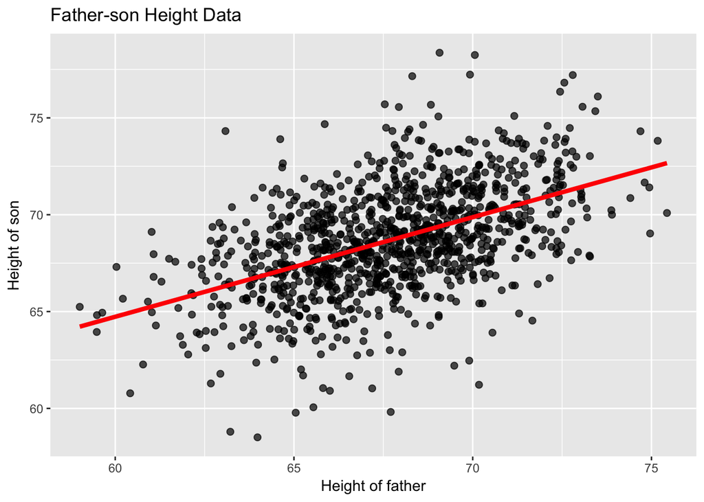

```
             Estimate Std. Error  t value     Pr(>|t|)
(Intercept) 33.886604 1.83235382 18.49348 1.604044e-66
x            0.514093 0.02704874 19.00618 1.121268e-69
```

```
       x
19.00618
```

```
For correlation of  0.5013383  , the test statistic is t =  19.00618 which gives a p-value less than 0.05. So the null hypothesis is rejected.
```

```
    Pearson's product-moment correlation

data:  x and y
t = 19.006, df = 1076, p-value < 2.2e-16
alternative hypothesis: true correlation is not equal to 0
95 percent confidence interval:
 0.4552586 0.5447396
sample estimates:
      cor
0.5013383
```

```
The 95% confidence interval for beta1 is  0.4610188 0.5671673
```

2. Refer to question 1. Interpret both parameters. Recenter for the intercept if necessary

```
             Estimate Std. Error  t value     Pr(>|t|)
(Intercept) 33.886604 1.83235382 18.49348 1.604044e-66
x            0.514093 0.02704874 19.00618 1.121268e-69
```

```
Slope estimate is  0.514093 . Which means that for each 1 increase in the father's height, there's will be a  0.514093  increase in the son's height.
```

```
Intercept estimate is  33.8866 . This would be a estimate of a son's height for a father of 0 inches - which of course would not be possible. Therefore this is irrelevant.
```

```
                Estimate Std. Error   t value     Pr(>|t|)
(Intercept)    68.684070 0.07421078 925.52689 0.000000e+00
I(x - mean(x))  0.514093 0.02704874  19.00618 1.121268e-69
```

```
Slope estimate is  0.514093 . Which means that for each 1 increase in the father's height, there's will be a  0.514093  increase in the son's height.
```

```
Intercept estimate is  68.68407 . This would be a estimate of a son's height for an average of father height.
```

3. Refer to question 1. Predict the son’s height if the father’s height is 80 inches. Would you recommend this prediction? Why or why not?

```r
fit <- lm(y~x)
predict(fit, newdata = data.frame(x = 80))
```

```
       1
75.01405
```

```r
summary(father.son)
```

```
    fheight         sheight
 Min.   :59.01   Min.   :58.51
 1st Qu.:65.79   1st Qu.:66.93
 Median :67.77   Median :68.62
 Mean   :67.69   Mean   :68.68
 3rd Qu.:69.60   3rd Qu.:70.47
 Max.   :75.43   Max.   :78.36
```

```r
# prediction is quite far from the center of the datset
# the prediction is in fact being the observed data
```

4. Load the mtcars dataset. Fit a linear regression with miles per gallon as the outcome and horsepower as the predictor. Interpret your coefficients, recenter for the intercept if necessary.

```
               Estimate Std. Error   t value     Pr(>|t|)
(Intercept) 30.09886054  1.6339210 18.421246 6.642736e-18
hp          -0.06822828  0.0101193 -6.742389 1.787835e-07
```

```
Slope estimate is  -0.06822828 . Which means that for each 1 increase in horsepower, there's will be a  -0.06822828  increase in miles per gallon. IN this case it will be a decrease because it's negative.
 This is highly statistically significant. Reject H0
```

```
                    Estimate Std. Error   t value     Pr(>|t|)
(Intercept)      20.09062500  0.6828817 29.420360 1.101810e-23
I(hp - mean(hp)) -0.06822828  0.0101193 -6.742389 1.787835e-07
```

```
Slope estimate is  -0.06822828 . Which means that for each 1 increase in horsepower, there's will be a  -0.06822828  increase in miles per gallon. IN this case it will be a decrease because it's negative.
 This is highly statistically significant. Reject H0
```

```
Intercept estimate is  20.09062 . This would be a estimate of mpg for an average of hp.
```

5. Refer to question 4. Overlay the fit onto a scatterplot.

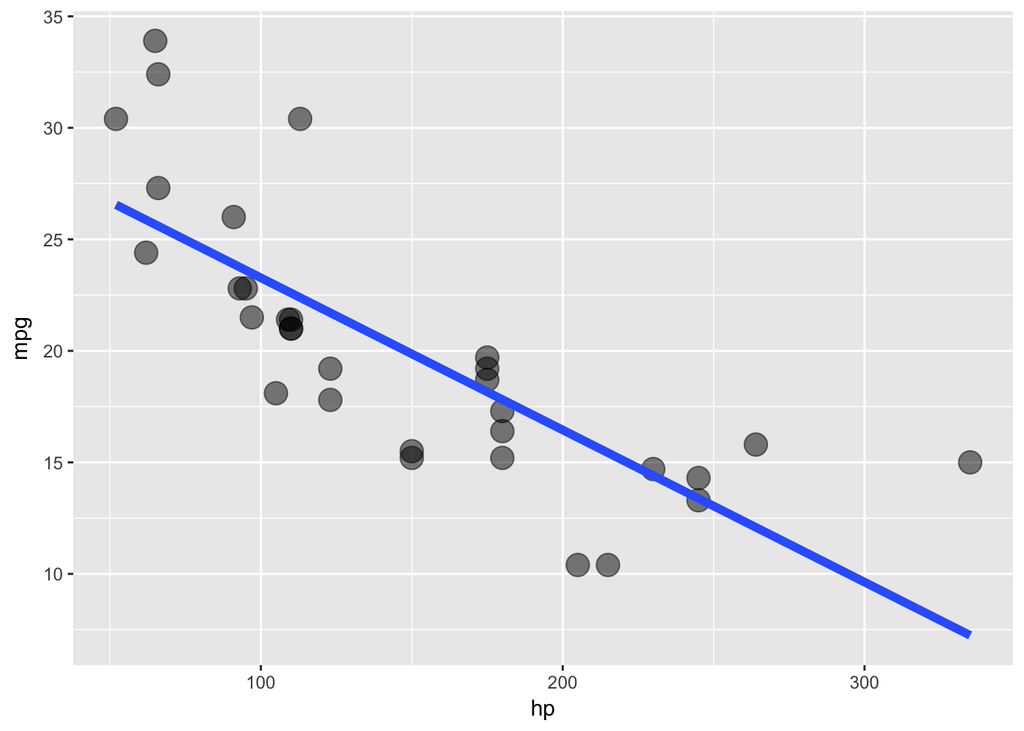

6. Refer to question 4. Test the hypothesis of no linear relationship between horsepower and miles per gallon.

```r
fit <- lm(mpg ~ hp, mtcars)
summary(fit)$coef
```

```
               Estimate Std. Error   t value     Pr(>|t|)
(Intercept) 30.09886054  1.6339210 18.421246 6.642736e-18
hp          -0.06822828  0.0101193 -6.742389 1.787835e-07
```

```r
# p-value for hp is 1*10^-7
# alpha is 0.05, so reject H0
```

7. Refer to question 4. Predict the miles per gallon for a horsepower of 111.

```r
fit <- lm(mpg ~ hp, mtcars)
predict(fit, newdata = data.frame(hp = 111))
```

```
       1
22.52552
```

```r
summary(mtcars)
```

```
      mpg             cyl             disp             hp             drat             wt
 Min.   :10.40   Min.   :4.000   Min.   : 71.1   Min.   : 52.0   Min.   :2.760   Min.   :1.513
 1st Qu.:15.43   1st Qu.:4.000   1st Qu.:120.8   1st Qu.: 96.5   1st Qu.:3.080   1st Qu.:2.581
 Median :19.20   Median :6.000   Median :196.3   Median :123.0   Median :3.695   Median :3.325
 Mean   :20.09   Mean   :6.188   Mean   :230.7   Mean   :146.7   Mean   :3.597   Mean   :3.217
 3rd Qu.:22.80   3rd Qu.:8.000   3rd Qu.:326.0   3rd Qu.:180.0   3rd Qu.:3.920   3rd Qu.:3.610
 Max.   :33.90   Max.   :8.000   Max.   :472.0   Max.   :335.0   Max.   :4.930   Max.   :5.424
      qsec             vs               am              gear            carb
 Min.   :14.50   Min.   :0.0000   Min.   :0.0000   Min.   :3.000   Min.   :1.000
 1st Qu.:16.89   1st Qu.:0.0000   1st Qu.:0.0000   1st Qu.:3.000   1st Qu.:2.000
 Median :17.71   Median :0.0000   Median :0.0000   Median :4.000   Median :2.000
 Mean   :17.85   Mean   :0.4375   Mean   :0.4062   Mean   :3.688   Mean   :2.812
 3rd Qu.:18.90   3rd Qu.:1.0000   3rd Qu.:1.0000   3rd Qu.:4.000   3rd Qu.:4.000
 Max.   :22.90   Max.   :1.0000   Max.   :1.0000   Max.   :5.000   Max.   :8.000
```